# Modelling performance barbell lifts

Ben Kooi

16-2-2022

## Synopsis

The goal of assignment is to analyze how effective the training is of barbell lifting based on the measurements of all kinds of body sensors. The effectiveness is classified as letters ‘A’ until ‘E’. The classification is modelled with three different algorithms treebagging, random forest and gradient boosting.

The outcome of the different models are the same on the 20 cases in the testing-set. The best performing model is the random forest-model and will be used to answer the questions of the Course Assignment Prediction Quiz.

## Setting the environment

```r
# loading the needed packages
packages <- c("caret", "janitor", "dplyr")
sapply(packages, require, character.only=TRUE, quietly=TRUE)
```

```
##   caret janitor   dplyr
##    TRUE    TRUE    TRUE
```

## Prepare the datasets

The following steps are taken to prepare the training and validation-datasets:  
1. Read the datasets for training and testing the models;  
2. The testing-dataset is the reference for the training- and validation-dataset, so at first the testing-dataset is cleaned;  
3. A new dataframe ‘data’ is constructed from the testing-dataset with only 49 of the original 160 variables. Most of the variables had no values at all;  
4. The dataframe ‘data’ is partitioned to the dataframes ‘training’ and ‘validation’.

```r
# load training and testing datasets where undefined values are converted to NA
data <- read.csv("https://d396qusza40orc.cloudfront.net/predmachlearn/pml-training.csv", na.strings = c("#DIV/0!", "NA", ""))
testing <- read.csv("https://d396qusza40orc.cloudfront.net/predmachlearn/pml-testing.csv", na.strings = c("#DIV/0!", "NA",""))

# remove empty columns from testing-dataset
testing <- remove_empty(testing, which = "cols")

# read the columnnames from the testing-dataset in a list
columnnames <- names(testing)

# remove the columname 'problem_id' from the list
columnnames <- columnnames[columnnames != "problem_id"]

# add the columname 'classe' to the list
columnnames <- c(columnnames, "classe")

# create a new dataframe from the selected columnnames of the testing-dataset
data <- data %>% select(all_of(columnnames))

# remove unnecessary columns from the dataframe
data <- subset(data, select = -c(X, user_name, raw_timestamp_part_1, raw_timestamp_part_2, num_window, new_window, cvtd_timestamp) )

# remove all the columns within the string 'total'
data <- data %>% select(-contains(c('total')))

# convert 'classe'-variable to factor
data$classe <- as.factor(data$classe)

# print the structure of the dataframe
str(data)
```

```
## 'data.frame':    19622 obs. of  49 variables:
##  $ roll_belt        : num  1.41 1.41 1.42 1.48 1.48 1.45 1.42 1.42 1.43 1.45 ...
##  $ pitch_belt       : num  8.07 8.07 8.07 8.05 8.07 8.06 8.09 8.13 8.16 8.17 ...
##  $ yaw_belt         : num  -94.4 -94.4 -94.4 -94.4 -94.4 -94.4 -94.4 -94.4 -94.4 -94.4 ...
##  $ gyros_belt_x     : num  0 0.02 0 0.02 0.02 0.02 0.02 0.02 0.02 0.03 ...
##  $ gyros_belt_y     : num  0 0 0 0 0.02 0 0 0 0 0 ...
##  $ gyros_belt_z     : num  -0.02 -0.02 -0.02 -0.03 -0.02 -0.02 -0.02 -0.02 -0.02 0 ...
##  $ accel_belt_x     : int  -21 -22 -20 -22 -21 -21 -22 -22 -20 -21 ...
##  $ accel_belt_y     : int  4 4 5 3 2 4 3 4 2 4 ...
##  $ accel_belt_z     : int  22 22 23 21 24 21 21 21 24 22 ...
##  $ magnet_belt_x    : int  -3 -7 -2 -6 -6 0 -4 -2 1 -3 ...
##  $ magnet_belt_y    : int  599 608 600 604 600 603 599 603 602 609 ...
##  $ magnet_belt_z    : int  -313 -311 -305 -310 -302 -312 -311 -313 -312 -308 ...
##  $ roll_arm         : num  -128 -128 -128 -128 -128 -128 -128 -128 -128 -128 ...
##  $ pitch_arm        : num  22.5 22.5 22.5 22.1 22.1 22 21.9 21.8 21.7 21.6 ...
```

[output cut: 35 more lines]

```r
# create training and validation-sets
trainIndex <- createDataPartition(data$classe, p=0.8, list=FALSE)
training <- data[ trainIndex,]
validation <- data[-trainIndex,]

# construct testing-set
data <- subset(data, select = -c(classe))
columnnames <- names(data)
testing <- testing %>% select(all_of(columnnames))
```

## Model selection

For selecting the most accurate model, three algorithms are chosen:  
* Treebagging;  
* Random Forest;  
* Gradient Boosting.

For tuning the algorithms, the dependent variable ‘classe’ will be calculated from all the other independent variables (predictors).

```r
set.seed(123)

# train a Treebagging-model with the default parameters and all the variables
modelTb <- train(classe ~ ., data=training, method="treebag")

# train a Random Forest-model with the default parameters and all the variables
modelRf <- train(classe ~ ., data=training, method="rf")

# train a Gradient Boosting-model with the default parameters and all the variables
modelGbm <- train(classe ~ ., data=training, method="gbm", verbose = FALSE)

# print the trained Treebagging-model
modelTb
```

```
## Bagged CART
##
## 15699 samples
##    48 predictor
##     5 classes: 'A', 'B', 'C', 'D', 'E'
##
## No pre-processing
## Resampling: Bootstrapped (25 reps)
## Summary of sample sizes: 15699, 15699, 15699, 15699, 15699, 15699, ...
## Resampling results:
##
##   Accuracy   Kappa
##   0.9795161  0.9740856
```

```r
# print the trained Random Forest-model
modelRf
```

```
## Random Forest
##
## 15699 samples
##    48 predictor
##     5 classes: 'A', 'B', 'C', 'D', 'E'
##
## No pre-processing
## Resampling: Bootstrapped (25 reps)
## Summary of sample sizes: 15699, 15699, 15699, 15699, 15699, 15699, ...
## Resampling results across tuning parameters:
##
##   mtry  Accuracy   Kappa
##    2    0.9904285  0.9878922
##   25    0.9904006  0.9878565
##   48    0.9830623  0.9785714
##
## Accuracy was used to select the optimal model using the largest value.
## The final value used for the model was mtry = 2.
```

```r
# print the trained Gradient Boosting-model
modelGbm
```

```
## Stochastic Gradient Boosting
##
## 15699 samples
##    48 predictor
##     5 classes: 'A', 'B', 'C', 'D', 'E'
##
## No pre-processing
## Resampling: Bootstrapped (25 reps)
## Summary of sample sizes: 15699, 15699, 15699, 15699, 15699, 15699, ...
## Resampling results across tuning parameters:
##
##   interaction.depth  n.trees  Accuracy   Kappa
##   1                   50      0.7512605  0.6844311
##   1                  100      0.8155799  0.7665298
##   1                  150      0.8483148  0.8080017
##   2                   50      0.8525406  0.8131188
##   2                  100      0.9049129  0.8796079
##   2                  150      0.9300404  0.9114417
##   3                   50      0.8953986  0.8675200
##   3                  100      0.9406143  0.9248250
##   3                  150      0.9590720  0.9481992
##
## Tuning parameter 'shrinkage' was held constant at a value of 0.1
##
## Tuning parameter 'n.minobsinnode' was held constant at a value of 10
## Accuracy was used to select the optimal model using the largest value.
## The final values used for the model were n.trees = 150, interaction.depth =
##  3, shrinkage = 0.1 and n.minobsinnode = 10.
```

## Final models

Based on the cross-validation of the different models, the best performing model in this case is Random Forest.

```r
set.seed(1234)

# train a Treebagging-model with the default parameters and all the variables
finalmodelTb <- train(classe ~ ., data=training, method="treebag")

# train a Random Forest-model with all the variables
finalmodelRf <- train(classe ~ .
                      , data=training
                      , method="rf"
                      , ntree=150
                      , tuneGrid = expand.grid(.mtry = 25))

# train a Gradient Boosting-model with all the variables
finalmodelGbm <- train(classe ~ .
                       , data=training
                       , method="gbm"
                       , tuneGrid = expand.grid(n.trees=150,
                                                interaction.depth=3,
                                                shrinkage=.1,
                                                n.minobsinnode = 10)
                       ,verbose = FALSE)

# predict with the final Treebagging-model
predictTb <- predict(finalmodelTb, validation)

# predict with the final Random Forest-model
predictRf <- predict(finalmodelRf, validation)

# predict with the final Random Forest-model
predictGbm <- predict(finalmodelGbm, validation)
```

## Out of sample errors

The best performing algorithm seem to be Random Forest.

```r
# Cross-validate the treebagging-algorithm and showing the confusionmatrix, overall statistics and calculate the out of sample error.
cmTb <- confusionMatrix(predictTb,validation$classe)
cmTb
```

```
## Confusion Matrix and Statistics
##
##           Reference
## Prediction    A    B    C    D    E
##          A 1105    8    1    1    0
##          B    6  738   11    5    1
##          C    2    9  668    8    2
##          D    2    2    4  628    4
##          E    1    2    0    1  714
##
## Overall Statistics
##
##                Accuracy : 0.9822
##                  95% CI : (0.9775, 0.9861)
##     No Information Rate : 0.2845
##     P-Value [Acc > NIR] : <2e-16
##
##                   Kappa : 0.9774
##
##  Mcnemar's Test P-Value : 0.5412
##
## Statistics by Class:
##
##                      Class: A Class: B Class: C Class: D Class: E
## Sensitivity            0.9901   0.9723   0.9766   0.9767   0.9903
## Specificity            0.9964   0.9927   0.9935   0.9963   0.9988
## Pos Pred Value         0.9910   0.9698   0.9695   0.9812   0.9944
## Neg Pred Value         0.9961   0.9934   0.9951   0.9954   0.9978
## Prevalence             0.2845   0.1935   0.1744   0.1639   0.1838
## Detection Rate         0.2817   0.1881   0.1703   0.1601   0.1820
## Detection Prevalence   0.2842   0.1940   0.1756   0.1631   0.1830
## Balanced Accuracy      0.9933   0.9825   0.9851   0.9865   0.9945
```

```r
cmTb$overall
```

```
##       Accuracy          Kappa  AccuracyLower  AccuracyUpper   AccuracyNull
##      0.9821565      0.9774309      0.9775090      0.9860644      0.2844762
## AccuracyPValue  McnemarPValue
##      0.0000000      0.5411653
```

```r
oosErrorTb <- 1 - cmTb$overall['Accuracy']

# Cross-validate the random forest-algorithm and showing the confusionmatrix, overall statistics and calculate the out of sample error.
cmRf <- confusionMatrix(predictRf,validation$classe)
cmRf
```

```
## Confusion Matrix and Statistics
##
##           Reference
## Prediction    A    B    C    D    E
##          A 1113    6    0    0    0
##          B    1  750    2    0    0
##          C    1    3  678    5    0
##          D    0    0    4  638    5
##          E    1    0    0    0  716
##
## Overall Statistics
##
##                Accuracy : 0.9929
##                  95% CI : (0.9897, 0.9953)
##     No Information Rate : 0.2845
##     P-Value [Acc > NIR] : < 2.2e-16
##
##                   Kappa : 0.991
##
##  Mcnemar's Test P-Value : NA
##
## Statistics by Class:
##
##                      Class: A Class: B Class: C Class: D Class: E
## Sensitivity            0.9973   0.9881   0.9912   0.9922   0.9931
## Specificity            0.9979   0.9991   0.9972   0.9973   0.9997
## Pos Pred Value         0.9946   0.9960   0.9869   0.9861   0.9986
## Neg Pred Value         0.9989   0.9972   0.9981   0.9985   0.9984
## Prevalence             0.2845   0.1935   0.1744   0.1639   0.1838
## Detection Rate         0.2837   0.1912   0.1728   0.1626   0.1825
## Detection Prevalence   0.2852   0.1919   0.1751   0.1649   0.1828
## Balanced Accuracy      0.9976   0.9936   0.9942   0.9947   0.9964
```

```r
cmRf$overall
```

```
##       Accuracy          Kappa  AccuracyLower  AccuracyUpper   AccuracyNull
##      0.9928626      0.9909718      0.9897009      0.9952522      0.2844762
## AccuracyPValue  McnemarPValue
##      0.0000000            NaN
```

```r
oosErrorRf <- 1 - cmRf$overall['Accuracy']

# Cross-validate the gradient boosting-algorithm and showing the confusionmatrix, overall statistics and calculate the out of sample error.
cmGbm <- confusionMatrix(predictGbm,validation$classe)
cmGbm
```

```
## Confusion Matrix and Statistics
##
##           Reference
## Prediction    A    B    C    D    E
##          A 1094   19    0    2    2
##          B   14  718   21    3   13
##          C    4   19  643   20    6
##          D    3    2   18  612   11
##          E    1    1    2    6  689
##
## Overall Statistics
##
##                Accuracy : 0.9574
##                  95% CI : (0.9506, 0.9635)
##     No Information Rate : 0.2845
##     P-Value [Acc > NIR] : < 2e-16
##
##                   Kappa : 0.9462
##
##  Mcnemar's Test P-Value : 0.03488
##
## Statistics by Class:
##
##                      Class: A Class: B Class: C Class: D Class: E
## Sensitivity            0.9803   0.9460   0.9401   0.9518   0.9556
## Specificity            0.9918   0.9839   0.9849   0.9896   0.9969
## Pos Pred Value         0.9794   0.9337   0.9292   0.9474   0.9857
## Neg Pred Value         0.9922   0.9870   0.9873   0.9905   0.9901
## Prevalence             0.2845   0.1935   0.1744   0.1639   0.1838
## Detection Rate         0.2789   0.1830   0.1639   0.1560   0.1756
## Detection Prevalence   0.2847   0.1960   0.1764   0.1647   0.1782
## Balanced Accuracy      0.9860   0.9649   0.9625   0.9707   0.9762
```

```r
cmGbm$overall
```

```
##       Accuracy          Kappa  AccuracyLower  AccuracyUpper   AccuracyNull
##     0.95743054     0.94615427     0.95063604     0.96353247     0.28447617
## AccuracyPValue  McnemarPValue
##     0.00000000     0.03487798
```

```r
oosErrorGbm <- 1 - cmGbm$overall['Accuracy']
```

The out of sample error of the three algorithms are:  
* treebagging -> **0.0178435**;  
* random forest -> **0.0071374**;  
* gradient boosting -> **0.0425695**.

## Prediction on 20 testcases

The three different algorithms classifies the 20 test-cases with the same values. There seems no need to ensemble or stack the algorithms to improve accuracy. The outcome of the 20 test-cases will not be shown and only used for answering the questions Course Assignment Prediction Quiz.

```r
# Predict the outcome of the testing-dataset with the final model of the treebagging-algorithm
predictTestCasesTb <- predict(finalmodelTb, testing)

# Predict the outcome of the testing-dataset with the final model of the random forest-algorithm
predictTestCasesRf <- predict(finalmodelRf, testing)

# Predict the outcome of the testing-dataset with the final model of the gradient-algorithm
predictTestCasesGbm <- predict(finalmodelGbm, testing)
```

## Plots

This section shows the plots on which the tuning-parameters are based on.

[figure not shown]

```r
plot(modelRf, main="Random Forest - Randomly selected variables vs. Accuracy")
```

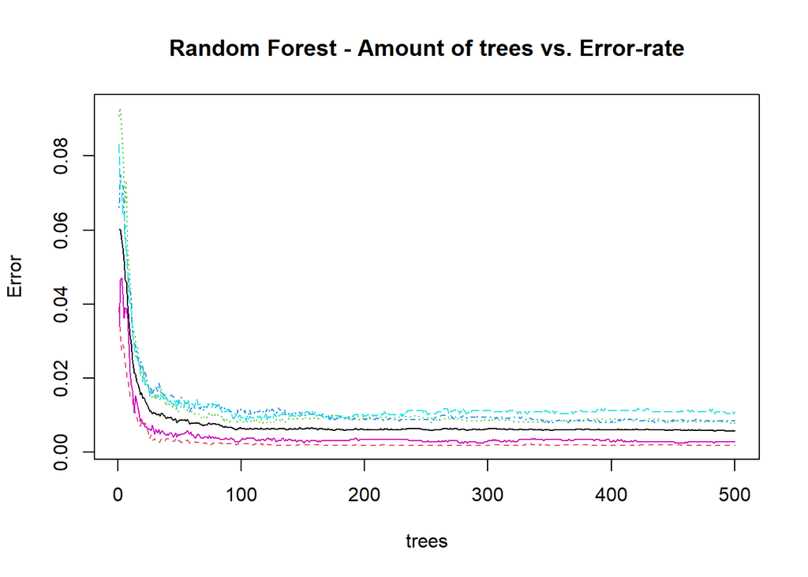

```r
plot(modelRf$finalModel, main="Random Forest - Amount of trees vs. Error-rate")
```

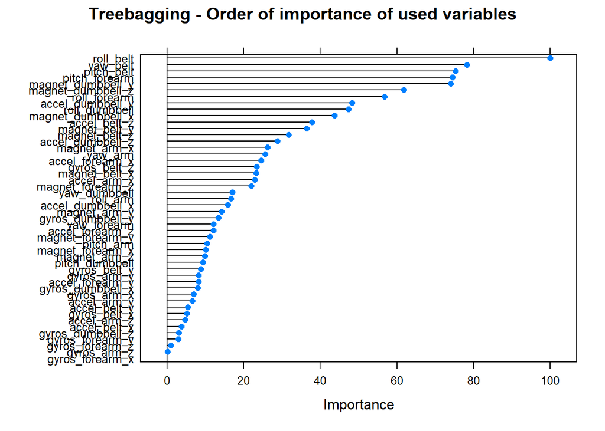

```r
plot(varImp(modelTb), main="Treebagging - Order of importance of used variables")
```

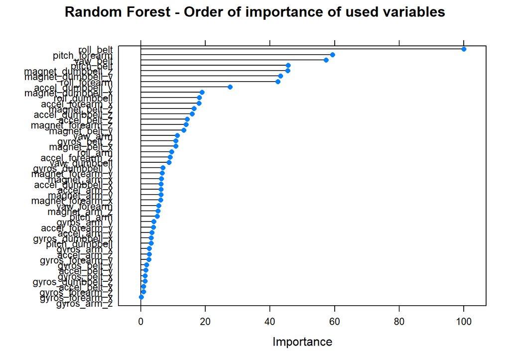

```r
plot(varImp(modelRf), main="Random Forest - Order of importance of used variables")
```

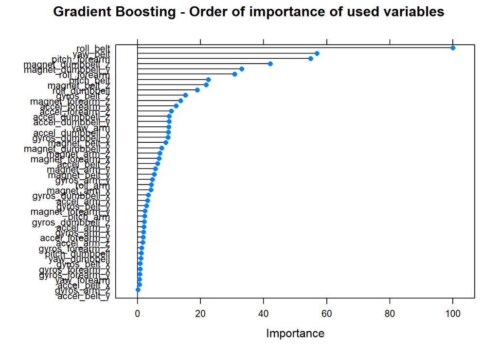

```r
plot(varImp(modelGbm),main="Gradient Boosting - Order of importance of used variables")
```